# Computer Workshop 7

Sean Longman

14/10/2021

## Load data

```r
alligato <- read_sav("Regression Modelling Data/alligato.sav")
```

## Clean data for binomial multiple logistic regression

```r
alligato <- alligato %>%
  mutate(
    eatsfish = case_when(CHOICE == 1 ~ 1, TRUE ~ 0)
  )

table(select(alligato, c(CHOICE, eatsfish)))
```

```
##       eatsfish
## CHOICE  0  1
##      1  0 33
##      2 20  0
##      3 10  0
```

### percentage of alligators who prefer fish

```r
100*sum(alligato$eatsfish)/nrow(alligato)
```

```
## [1] 52.38095
```

## plot eatsfish against length using sex as marker

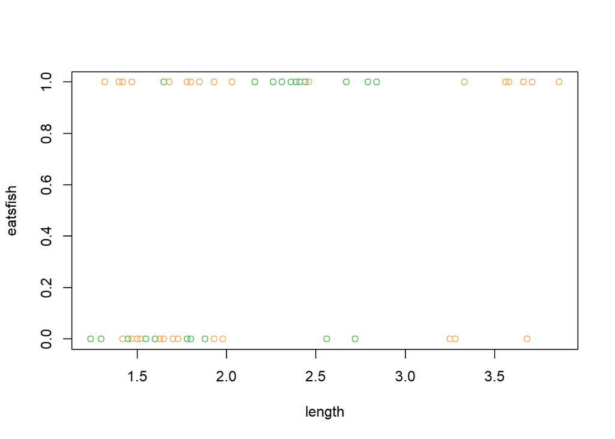

```r
colors <- c("#FDAE61","#66BD63")
plot(alligato$LENGTH, alligato$eatsfish, col = colors[factor(alligato$SEX)],
     xlab = "length", ylab = "eatsfish")
```

## Clustered boxplot

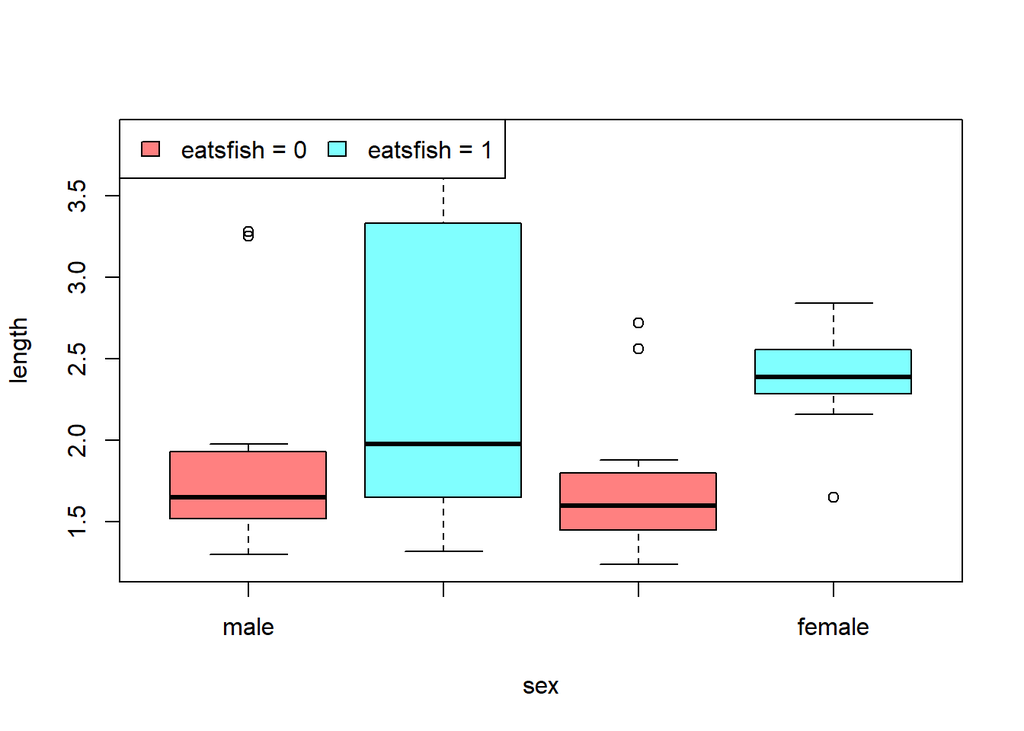

```r
cols <- rainbow(2, s = 0.5)
boxplot(alligato$LENGTH ~ alligato$eatsfish + alligato$SEX,
        xlab = "sex", ylab = "length", names = c("male","","","female"), col = cols)
legend("topleft", fill = cols, legend = c("eatsfish = 0", "eatsfish = 1"), horiz = T)
```

## Fit simple logistic model

```r
fit1 <- glm(eatsfish ~ LENGTH + as.factor(SEX), data = alligato, family = binomial)
summary(fit1)
```

```
##
## Call:
## glm(formula = eatsfish ~ LENGTH + as.factor(SEX), family = binomial,
##     data = alligato)
##
## Deviance Residuals:
##     Min       1Q   Median       3Q      Max
## -2.0619  -1.0339   0.4966   1.1019   1.4398
##
## Coefficients:
##                 Estimate Std. Error z value Pr(>|z|)
## (Intercept)      -1.9543     0.9425  -2.073   0.0381 *
## LENGTH            1.0741     0.4495   2.390   0.0169 *
## as.factor(SEX)2  -0.4165     0.5493  -0.758   0.4482
## ---
## Signif. codes:  0 '***' 0.001 '**' 0.01 '*' 0.05 '.' 0.1 ' ' 1
##
## (Dispersion parameter for binomial family taken to be 1)
##
##     Null deviance: 87.194  on 62  degrees of freedom
## Residual deviance: 79.422  on 60  degrees of freedom
## AIC: 85.422
##
## Number of Fisher Scoring iterations: 3
```

## remove sex from model

```r
fit2 <- glm(eatsfish ~ LENGTH, data = alligato, family = binomial)
summary(fit2)
```

```
##
## Call:
## glm(formula = eatsfish ~ LENGTH, family = binomial, data = alligato)
##
## Deviance Residuals:
##     Min       1Q   Median       3Q      Max
## -1.9749  -1.0362   0.5459   1.0420   1.4805
##
## Coefficients:
##             Estimate Std. Error z value Pr(>|z|)
## (Intercept)  -2.0794     0.9091  -2.287   0.0222 *
## LENGTH        1.0533     0.4332   2.431   0.0150 *
## ---
## Signif. codes:  0 '***' 0.001 '**' 0.01 '*' 0.05 '.' 0.1 ' ' 1
##
## (Dispersion parameter for binomial family taken to be 1)
##
##     Null deviance: 87.194  on 62  degrees of freedom
## Residual deviance: 80.001  on 61  degrees of freedom
## AIC: 84.001
##
## Number of Fisher Scoring iterations: 4
```

## Predict the values

```r
alligato$glm_probs <- predict(fit2, type = "response")
```

## Compute marginal effects

```r
alligato$d_length <- alligato$glm_probs*(1-alligato$glm_probs)*1.053
```

## Scatter plot of marginal effects against the length variable

[figure not shown]

```r
cols  <- rainbow(2,s=0.5)
plot(alligato$d_length ~ alligato$LENGTH, col = cols)
legend("topright", fill = cols, legend = c("sex = male", "sex = female"), horiz = T)
```

### The predicted proability of a 1.6m alligator and a 1.5m alligator eating fish

```r
predict(fit2, newdata = data.frame(LENGTH = c(1.6,1.5)), type = "response")
```

```
##         1         2
## 0.4027158 0.3776605
```

## Marginal effect of length on the probability of eating fish for male and female alligators

```r
mean(alligato$d_length[alligato$SEX == 1])
```

```
## [1] 0.2271955
```

```r
mean(alligato$d_length[alligato$SEX == 2])
```

```
## [1] 0.2463868
```

## Hosmer-Lemeshow test

```r
hl <- hoslem.test(alligato$eatsfish, fitted(fit2),g = 10)
hl
```

```
##
##  Hosmer and Lemeshow goodness of fit (GOF) test
##
## data:  alligato$eatsfish, fitted(fit2)
## X-squared = 10.819, df = 8, p-value = 0.2122
```

```r
cbind(hl$observed, hl$expected)
```

```
##               y0 y1    yhat0     yhat1
## [0.316,0.358]  4  4 5.287254 2.7127456
## (0.358,0.38]   4  1 3.151084 1.8489160
## (0.38,0.415]   8  2 5.934261 4.0657389
## (0.415,0.434]  1  1 1.148571 0.8514287
## (0.434,0.454]  5  2 3.859314 3.1406863
## (0.454,0.515]  3  4 3.549852 3.4501477
## (0.515,0.6]    0  6 2.501119 3.4988809
## (0.6,0.665]    1  4 1.884483 3.1155171
## (0.665,0.805]  3  3 1.630460 4.3695398
## (0.805,0.879]  1  6 1.053601 5.9463990
```

## interaction terms

```r
fit4 <- glm(eatsfish ~LENGTH + as.factor(SEX), data = alligato, family = binomial)
summary(fit4)
```

```
##
## Call:
## glm(formula = eatsfish ~ LENGTH + as.factor(SEX), family = binomial,
##     data = alligato)
##
## Deviance Residuals:
##     Min       1Q   Median       3Q      Max
## -2.0619  -1.0339   0.4966   1.1019   1.4398
##
## Coefficients:
##                 Estimate Std. Error z value Pr(>|z|)
## (Intercept)      -1.9543     0.9425  -2.073   0.0381 *
## LENGTH            1.0741     0.4495   2.390   0.0169 *
## as.factor(SEX)2  -0.4165     0.5493  -0.758   0.4482
## ---
## Signif. codes:  0 '***' 0.001 '**' 0.01 '*' 0.05 '.' 0.1 ' ' 1
##
## (Dispersion parameter for binomial family taken to be 1)
##
##     Null deviance: 87.194  on 62  degrees of freedom
## Residual deviance: 79.422  on 60  degrees of freedom
## AIC: 85.422
##
## Number of Fisher Scoring iterations: 3
```

```r
fit5 <- glm(eatsfish ~LENGTH * as.factor(SEX), data = alligato, family = binomial)
summary(fit5)
```

```
##
## Call:
## glm(formula = eatsfish ~ LENGTH * as.factor(SEX), family = binomial,
##     data = alligato)
##
## Deviance Residuals:
##     Min       1Q   Median       3Q      Max
## -2.1307  -1.1393   0.4142   1.0191   1.9267
##
## Coefficients:
##                        Estimate Std. Error z value Pr(>|z|)
## (Intercept)             -0.9198     0.9529  -0.965   0.3344
## LENGTH                   0.5586     0.4336   1.288   0.1976
## as.factor(SEX)2         -6.6988     3.0126  -2.224   0.0262 *
## LENGTH:as.factor(SEX)2   3.0368     1.4048   2.162   0.0306 *
## ---
## Signif. codes:  0 '***' 0.001 '**' 0.01 '*' 0.05 '.' 0.1 ' ' 1
##
## (Dispersion parameter for binomial family taken to be 1)
##
##     Null deviance: 87.194  on 62  degrees of freedom
## Residual deviance: 73.126  on 59  degrees of freedom
## AIC: 81.126
##
## Number of Fisher Scoring iterations: 4
```

## Omnibus test

```r
anova(fit5, test = "Chisq")
```

```
## Analysis of Deviance Table
##
## Model: binomial, link: logit
##
## Response: eatsfish
##
## Terms added sequentially (first to last)
##
##
##                       Df Deviance Resid. Df Resid. Dev Pr(>Chi)
## NULL                                     62     87.194
## LENGTH                 1   7.1922        61     80.001 0.007322 **
## as.factor(SEX)         1   0.5793        60     79.422 0.446578
## LENGTH:as.factor(SEX)  1   6.2959        59     73.126 0.012102 *
## ---
## Signif. codes:  0 '***' 0.001 '**' 0.01 '*' 0.05 '.' 0.1 ' ' 1
```

Model on the logit scale logit(pi) = -0.920 + 0.559 * LENGTH - 6.699 * SEX(2) + 3.037 * LENGTH*SEX(2) MALES: logit(pi) = -0.920 + 0.559* LENGTH FEMALES: logit(pi) = -0.920 + 0.559 * LENGTH - 6.699 * 1 + 3.037 * LENGTH*1 = -7.619 + 3.596* LENGTH

Model on the odds scale: pi/(1-pi) = exp(-0.920 + 0.559 * LENGTH - 6.699 * SEX(2) + 3.037 * LENGTH*SEX(2))

Model on the probability scale: pi = exp(-0.920 + 0.559 * LENGTH - 6.699 * SEX(2) + 3.037 * LENGTH*SEX(2))/(1+exp(-0.920 + 0.559* LENGTH - 6.699 * SEX(2) + 3.037 * LENGTH*SEX(2)))

### Predict for 1.6m male and 1.5m female

```r
predict(fit5, newdata = data.frame(LENGTH = c(1.6,1.5), SEX = c(1,2)), type = "response")
```

```
##          1          2
## 0.49348736 0.09748293
```

Scatter plot of predicted probabilities

[figure not shown]

```r
alligato$fit5_probs <- predict(fit5, type = "response")
cols  <- rainbow(2,s=0.5)
plot(fit5_probs ~ LENGTH, data = alligato, xlim = c(0,4), ylim = c(0,1), col = cols)
legend("topleft", fill = cols, legend = c("sex = male", "sex = female"), horiz = T)
```